# Final Exam

Melvin van der Mark

27-June-2024

# 1 Introduction

Precision medicine is becoming increasinly relevant in the field of oncology. Comprehensive genomic profiling (CGP) allows for the detailed analysis of tumor tissue. New methods such as next-generation sequencing (NGS) can identify various type of alterations such as: mutations, amplifications, rearragements, fusions and more. The identification of these alterations can help with treatment decisions in the field of targeted therapy. These therapies target the specific alterations found.

# 2 Data Description

The dataset used contains alterations found for different cancer diagnoses, all patients with solid tumor types were included in the dataset. Gene testing for hematological cancer types to exist, but are not covered in this dataset. The patients were recruited between 2016 and 2022. In addition, the dataset includes other variables such as age, gender, year of birth, date of test, date of result, and test panel.

## 2.1 Test

All the patients were tested with the same NGS test using CGP by exploring 323 genes in samples from the tumor. The test were conducted from 2016 - 2022 to get the most relevant results. A number of alterations have related systemtherapies which are then recommended based on not just the gene alteration but also the diagnosis and other factors.

## 2.2 Gene panel

ABL1, ABL2, ACVR1B, AKT1, AKT2, AKT3, ALK, AMER1 (FAM123B), APC, AR, ARAF, ARFRP1, ARID1A, ARID1B, ARID2, ASXL1, ATM, ATR, ATRX, AURKA, AURKB, AXIN1, AXL, BAP1, BARD1, BCL2, BCL2L1, BCL2L2, BCL6, BCOR, BCORL1, BCR, BLM, BRAF, BRCA1, BRCA2, BRD4, BRIP1, BTG1, BTK, C11orf30 (EMSY), CARD11, CBFB, CBL, CCND1, CCND2, CCND3, CCNE1, CD274, CD79A, CD79B, CDC73, CDH1, CDK12, CDK4, CDK6, CDK8, CDKN1A, CDKN1B, CDKN2A, CDKN2B, CDKN2C, CEBPA, CHD2, CHD4, CHEK1, CHEK2, CIC, CREBBP, CRKL, CRLF2, CSF1R, CTCF, CTNNA1, CTNNB1, CUL3, CYLD, DAXX, DDR2, DICER1, DNMT3A, DOT1L, EGFR, EP300, EPHA3, EPHA5, EPHA7, EPHB1, ERBB2, ERBB3, ERBB4, ERG, ERRFI1, ESR1, ETV1, ETV4, ETV5, ETV6, EZH2, FAM123B, FAM46C, FANCA, FANCC, FANCD2, FANCE, FANCF, FANCG, FANCL, FAS, FAT1, FBXW7, FGF10, FGF14, FGF19, FGF23, FGF3, FGF4, FGF6, FGFR1, FGFR2, FGFR3, FGFR4, FH, FLCN, FLT1, FLT3, FLT4, FOXL2, FOXP1, FRS2, FUBP1, GABRA6, GATA1, GATA2, GATA3, GATA4, GATA6, GID4 (C17orf39), GLI1, GNA11, GNA13, GNAQ, GNAS, GPR124, GRIN2A, GRM3, GSK3B, H3F3A, HGF, HNF1A, HRAS, HSD3B1, HSP90AA1, IDH1, IDH2, IGF1R, IGF2, IKBKE, IKZF1, IL7R, INHBA, INPP4B, IRF2, IRF4, IRS2, JAK1, JAK2, JAK3, JUN, KAT6A (MYST3), KDM5A, KDM5C, KDM6A, KDR, KEAP1, KEL, KIT, KLHL6, KMT2A (MLL), KMT2C (MLL3), KMT2D (MLL2), KRAS, LMO1, LRP1B, LYN, LZTR1, MAGI2, MAP2K1, MAP2K2, MAP2K4, MAP3K1, MCL1, MDM2, MDM4, MED12, MEF2B, MEN1, MET, MITF, MLH1, MPL, MRE11A, MSH2, MSH6, MTOR, MUTYH, MYB, MYC, MYCL (MYCL1), MYCN, MYD88, NF1, NF2, NFE2L2, NFKBIA, NKX2-1, NOTCH1, NOTCH2, NOTCH3, NPM1, NRAS, NSD1, NTRK1, NTRK2, NTRK3, NUP93, PAK3, PALB2, PARK2, PAX5, PBRM1, PDCD1LG2, PDGFRA, PDGFRB, PDK1, PIK3C2B, PIK3CA, PIK3CB, PIK3CG, PIK3R1, PIK3R2, PLCG2, PMS2, POLD1, POLE, PPP2R1A, PRDM1, PREX2, PRKAR1A, PRKCI, PRKDC, PRSS8, PTCH1, PTEN, PTPN11, QKI, RAC1, RAD50, RAD51, RAF1, RANBP2, RARA, RB1, RBM10, RET, RICTOR, RNF43, ROS1, RPTOR, RUNX1, RUNX1T1, SDHA, SDHB, SDHC, SDHD, SETD2, SF3B1, SLIT2, SMAD2, SMAD3, SMAD4, SMARCA4, SMARCB1, SMO, SNCAIP, SOCS1, SOX10, SOX2, SOX9, SPEN, SPOP, SPTA1, SRC, STAG2, STAT3, STAT4, STK11, SUFU, SYK, TAF1, TBX3, TERC, TERT (promoter only), TET2, TGFBR2, TMPRSS2, TNFAIP3, TNFRSF14, TOP1, TOP2A, TP53, TSC1, TSC2, TSHR, U2AF1, VEGFA, VHL, WISP3, WT1, XPO1, ZBTB2, ZNF217, ZNF703

## 2.3 Dataset

The variables part of the dataset are described in more detail in the table below:

| Variable Name | Description |
| --- | --- |
| Patientnr | unique identifier |
| gender | gender either “m” male “f” female |
| yob | year of birth, only contains the year in 4 digits |
| diagnose_group | diagnosis grouped according to the ICD-10 classification |
| diagnose | diagnosis, only solid tumor types included |
| cycle | number of test, a patient can have multiple |
| test_date | Date the test was performed |
| result_date | Date the test report was ready |
| alts_y_n | Did the test identify any alteration yes or no |
| recs_y_n | Does the alteration bring specific recommendations yes or no |
| alteration | Name of different genes |
| type | Type of alteration found, abbreviated like mut (mutation), amp (amplification), loss |
| details | Details on the specific alteration, this can be for instance a protein |

# 3 Data processing

## 3.1 ICD-10 Groups

Below you find an overview of the data in table format.

|  | patientnr | gender | yob | diagnose_group | diagnose | cycle | test_date | result_date | alts_y_n | recs_y_n | alteration | type | details |
| --- | --- | --- | --- | --- | --- | --- | --- | --- | --- | --- | --- | --- | --- |
| 1 | 100001 | f | 1942 | Malignant neoplasms of respiratory and intrathoracic organs | NSCLC | 1 | 23.10.2019 | 31.10.2019 | 1 | yes | KRAS, SMAD4, CDKN2B, PALB2, MTAP, CDKN2A | mut, mut, loss, mut, loss, loss | Q61K \| S343 \| loss \| Y1183 \| loss \| loss |
| 2 | 100002 | f | 1960 | Malignant neoplasms of digestive organs | Pancreatic cancer | 1 | 30.10.2019 | 10.11.2019 | 1 | no | SMARCA4, MYC | other, amp | loss \| amplification |
| 3 | 100003 | m | 1968 | Malignant neoplasms of digestive organs | Pancreatic cancer | 1 | 30.10.2019 | 10.11.2019 | 1 | no | SMAD4 | mut | P356L |
| 4 | 100004 | f | 1958 | Malignant neoplasm of breast | Breast cancer | 1 | 30.10.2019 | 10.11.2019 | 1 | yes | ARAF, TP53, CUL4A, NOTCH3 | amp, mut, amp, mut | equivocal \| Q165* \| equivocal \| S968fs*66 |
| 5 | 100005 | f | 1964 | Malignant neoplasm of breast | Breast cancer | 1 | 13.11.2019 | 21.11.2019 | 1 | yes | FGF10, MTAP, PRKCI, TP53, RICTOR, BRAF, CDKN2A, NRAS, CDKN2B, TERC | amp, loss, amp, mut, amp, mut, loss, mut, loss, amp | amplification \| loss \| amplification \| E221 \| amplification \| D594N \| loss \| G12C \| loss \| amplification |
| 6 | 100006 | f | 1975 | Sarcoma | PEComa | 1 | 13.11.2019 | 25.11.2019 | 1 | yes | CDKN2B, TP53, CHEK2, CDKN2A, TSC2 | mut, mut, mut, mut, mut | p14ARF R115L \| G105D \| I157T \| p16INK4a G101W \| splice site 2356-16&gt;A |

Before we can analyze the data we need to get an overview of frequencies and distributions.

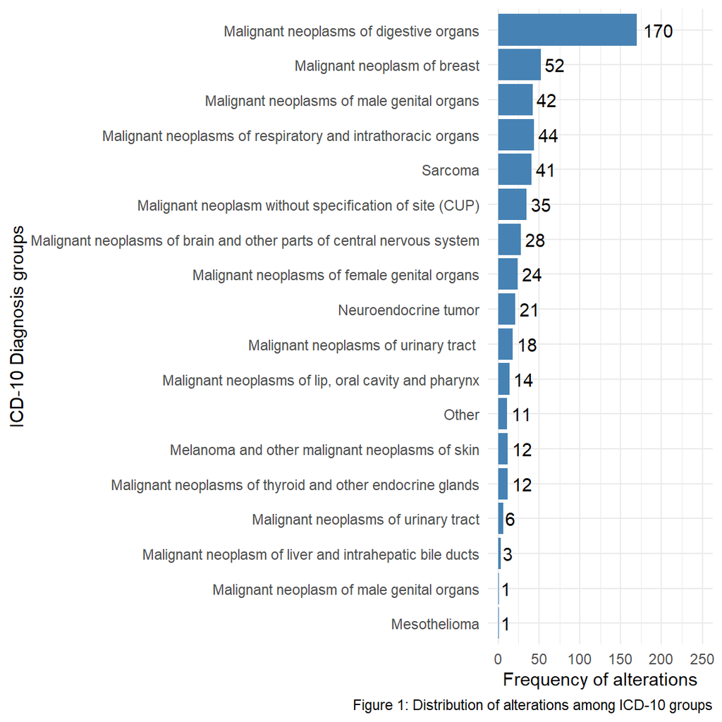

It would seem that some groups are rather small

Table 3.1: Counts and Percentages per Diagnose Group

| N | diagnose_group | n | percentage |
| --- | --- | --- | --- |
| 1 | Malignant neoplasms of digestive organs | 170 | 31.78 |
| 2 | Malignant neoplasm of breast | 52 | 9.72 |
| 3 | Malignant neoplasms of respiratory and intrathoracic organs | 44 | 8.22 |
| 4 | Malignant neoplasms of male genital organs | 42 | 7.85 |
| 5 | Sarcoma | 41 | 7.66 |
| 6 | Malignant neoplasm without specification of site (CUP) | 35 | 6.54 |
| 7 | Malignant neoplasms of brain and other parts of central nervous system | 28 | 5.23 |
| 8 | Malignant neoplasms of female genital organs | 24 | 4.49 |
| 9 | Neuroendocrine tumor | 21 | 3.93 |
| 10 | Malignant neoplasms of urinary tract | 18 | 3.36 |
| 11 | Malignant neoplasms of lip, oral cavity and pharynx | 14 | 2.62 |
| 12 | Malignant neoplasms of thyroid and other endocrine glands | 12 | 2.24 |
| 13 | Melanoma and other malignant neoplasms of skin | 12 | 2.24 |
| 14 | Other | 11 | 2.06 |
| 15 | Malignant neoplasms of urinary tract | 6 | 1.12 |
| 16 | Malignant neoplasm of liver and intrahepatic bile ducts | 3 | 0.56 |
| 17 | Malignant neoplasm of male genital organs | 1 | 0.19 |
| 18 | Mesothelioma | 1 | 0.19 |

# 4 Analysis 1: logistic regression

## 4.1 Occurence of an alteration - logistic regression

### 4.1.1 The model

| **Characteristic** | **log(OR)**<sup>1</sup> | **95% CI**<sup>1</sup> | **p-value** |
| --- | --- | --- | --- |
| diagnose_group |  |  |  |
| Malignant neoplasms of digestive organs | — | — |  |
| Malignant neoplasm of breast | -0.40 | -1.5, 0.79 | 0.5 |
| Malignant neoplasms of male genital organs | 0.45 | -0.67, 1.8 | 0.5 |
| Malignant neoplasms of respiratory and intrathoracic organs | -0.09 | -1.1, 1.1 | 0.9 |
| Sarcoma | 0.01 | -1.1, 1.3 | >0.9 |
| Malignant neoplasm without specification of site (CUP) | 1.3 | -0.38, 4.2 | 0.2 |
| Malignant neoplasms of brain and other parts of central nervous system | 0.46 | -0.91, 2.4 | 0.6 |
| Malignant neoplasms of female genital organs | 0.10 | -1.4, 2.0 | >0.9 |
| Neuroendocrine tumor | -0.29 | -1.6, 1.3 | 0.7 |
| Malignant neoplasms of urinary tract | 16 | -49, NA | >0.9 |
| Malignant neoplasms of lip, oral cavity and pharynx | -0.13 | -1.6, 1.8 | 0.9 |
| Other | -1.1 | -2.3, 0.33 | 0.11 |
| Melanoma and other malignant neoplasms of skin | -0.59 | -2.1, 1.4 | 0.5 |
| Malignant neoplasms of thyroid and other endocrine glands | 16 | -90, NA | >0.9 |
| gender |  |  |  |
| f | — | — |  |
| m | -0.30 | -1.0, 0.41 | 0.4 |
| yob | 0.00 | -0.02, 0.03 | 0.7 |

<sup>1</sup> OR = Odds Ratio, CI = Confidence Interval

### 4.1.2 Evaluation

```
## Confusion Matrix and Statistics
##
##           Reference
## Prediction   0   1
##          0   0   0
##          1  30 152
##
##                Accuracy : 0.8352
##                  95% CI : (0.7731, 0.8859)
##     No Information Rate : 0.8352
##     P-Value [Acc > NIR] : 0.5485
##
##                   Kappa : 0
##
##  Mcnemar's Test P-Value : 1.192e-07
##
##             Sensitivity : 0.0000
##             Specificity : 1.0000
##          Pos Pred Value :    NaN
##          Neg Pred Value : 0.8352
##              Prevalence : 0.1648
##          Detection Rate : 0.0000
##    Detection Prevalence : 0.0000
##       Balanced Accuracy : 0.5000
##
##        'Positive' Class : 0
##
```

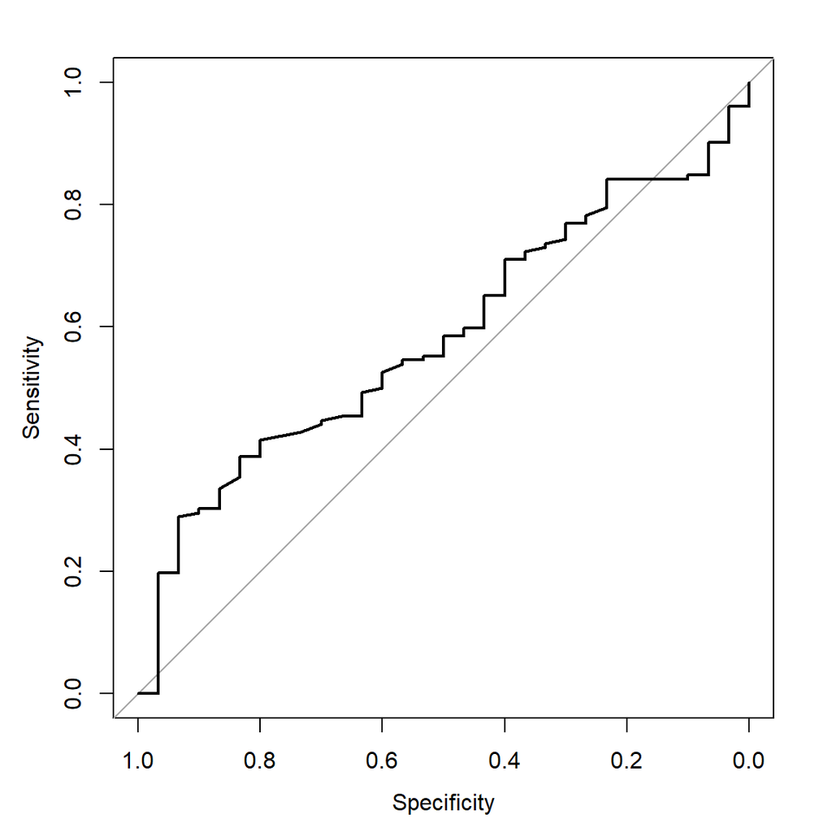

```
## Area under the curve: 0.5829
```

```
##                    GVIF Df GVIF^(1/(2*Df))
## diagnose_group 1.634504 13        1.019077
## gender         1.467907  1        1.211572
## yob            1.117951  1        1.057332
```

The Variance inflation factor (VIF) is a measure to detect multicollinearity in regression models. High VIF values indicate high multicollinearity between the predictor variables. The number of predictors suggest there is moderate to no multicollinearity between the predictors.

# 5 Analysis 2: random forest

## 5.1 Occurence of an alteration - random forest

```
## Random Forest
##
## 374 samples
##   3 predictor
##
## No pre-processing
## Resampling: Bootstrapped (25 reps)
## Summary of sample sizes: 374, 374, 374, 374, 374, 374, ...
## Resampling results across tuning parameters:
##
##   mtry  RMSE  Rsquared  MAE
##    2    0     NaN       0
##    3    0     NaN       0
##    4    0     NaN       0
##    6    0     NaN       0
##    7    0     NaN       0
##    9    0     NaN       0
##   10    0     NaN       0
##   12    0     NaN       0
##   13    0     NaN       0
##   15    0     NaN       0
##
## RMSE was used to select the optimal model using the smallest value.
## The final value used for the model was mtry = 2.
```

[figure not shown]

There are different mtry, number of variables randomly sampled as candidates each split. However, RMSE, Rsquared and MAE are all 0 or NaN. meaning that the model could not be completed. One would normally choose the mtry value where the RMSE and MAE be lower and Rsquared higher for better model fit.

```
## Confusion Matrix and Statistics
##
##           Reference
## Prediction   0   1
##          0   0   0
##          1   0 151
##
##                Accuracy : 1
##                  95% CI : (0.9759, 1)
##     No Information Rate : 1
##     P-Value [Acc > NIR] : 1
##
##                   Kappa : NaN
##
##  Mcnemar's Test P-Value : NA
##
##             Sensitivity : NA
##             Specificity :  1
##          Pos Pred Value : NA
##          Neg Pred Value : NA
##              Prevalence :  0
##          Detection Rate :  0
##    Detection Prevalence :  0
##       Balanced Accuracy : NA
##
##        'Positive' Class : 0
##
```

Since there is only one value of both the predictions and reference, which does not leave much to work with.

# 6 Conclusion and next steps

The question if it is possible to predict the possibility of finding an alteration based on the different ICD-10 groups.

Both models were no good fit, which might be cause of the dataset or the methods used. The logistic regression did not say any signficant predictor, and the random forest model did not provide more information.

Next steps would be to explore other methods, or consider the dataset inappropriate.